# SOLUTIONS: Exam 01: Open Notes Portion

DSST289: Introduction to Data Science

Author

Erik Fredner

Published

September 29, 2024

# 1 Deadline

Wednesday, September 18 *before* the start of class.

# 2 Honor Pledge

“I pledge that I will neither give nor receive unauthorized assistance during the completion of this work.”

For exams in this class, “unauthorized assistance” includes but is not limited to: discussing exam questions with anyone else, using generative artificial intelligence (e.g., ChatGPT), and/or copying others’ work.

You may use class notes, notebooks, slides, etc.

**Signature (type your full name)**:

**UR email:**

**Section start time:**

# 3 Setup

0. Navigate to Blackboard > Course Documents > Exams > Exam 01
1. Download this exam from Blackboard: `exam01_open.Rmd`
2. Download the data from Blackboard: `domestic_cats.csv`
3. Move the exam to the `nb` folder in your `DSST289` folder, just as we do when working on new notebooks in class: (`...DSST289/nb/exam01_open.Rmd`)
4. Move the data to the `data` folder in your `DSST289` folder: (`...DSST289/data/domestic_cats.csv`)
5. Test that your setup is correct by running the code blocks below:

```r
library(tidyverse)
library(ggrepel)

cats <- read_csv("~/code/dsst289-2024/data/domestic_cats.csv")
```

```r
# preview a random sample of the data:
cats |>
  slice_sample(n = 10)
```

| name | event_id | month | long | lat | indoors_min | indoors_max | prey_month | age | sex |
| --- | --- | --- | --- | --- | --- | --- | --- | --- | --- |
| Kitty | 737747700 | 6 | 138.6332 | -34.86240 | 0 | 5 | 1 | 4 | m |
| Muss | 979898106 | 8 | 138.7034 | -34.84816 | 12 | 17 | 1 | 7 | m |
| Lilliput | 855762190 | 6 | 138.6652 | -34.85762 | 18 | 24 | 3 | 3 | f |
| Jinx | 1165780981 | 2 | 138.5970 | -34.90691 | 6 | 11 | 10 | 6 | f |
| Matilda | 713430989 | 5 | 138.5384 | -35.00189 | 12 | 17 | 1 | 8 | f |
| MapleSyrup | 812534756 | 6 | 138.7056 | -34.91340 | 18 | 24 | 0 | 10 | f |
| Ruby | 1102565066 | 8 | 138.6075 | -34.94362 | 12 | 17 | 2 | 3 | f |
| Lilliput | 855763975 | 7 | 138.6654 | -34.85762 | 18 | 24 | 3 | 3 | f |
| Ernie | 684729648 | 5 | 138.6039 | -34.94571 | 0 | 5 | 0 | 11 | m |
| Darcy | 850683012 | 7 | 138.7000 | -34.86837 | 12 | 17 | 4 | 8 | m |

# 4 Instructions

1. Although there are multiple ways of producing the results requested in each question, I expect to see you use patterns and techniques that we have discussed.
2. If you are unable to complete a question, explain your attempt to maximize partial credit.
3. If you encounter R errors that you cannot resolve on your own, contact me ASAP. I can help you with configuration issues, but will not help you answer questions.
4. When complete, **knit** your `.Rmd` file to `.pdf`. (If you have forgotten how to do this, check the slides for class 06.)
5. Go to Blackboard > Assignments > Exam 01 (open notes). Upload your **knitted** `.pdf` document.
- Blackboard does not permit you to upload the `.html` files. Knit to `.pdf` instead.
- If knitting to `.pdf` does not work on your machine, compress a knitted `.html` file into a `.zip` file and upload that.
- If you cannot either create a `.pdf` or a `.zip` file, email me your `.html` file.

# 5 Exam 01

## 5.1 Data: Pet Cats in Adelaide, Australia

The data set for this exam consists of a set of recorded locations for twenty domestic cats (household pet cats) in Adelaide, Australia. Each cat wore a GPS tracking device which periodically recorded that cat’s location. We will work with a random sample of up to 150 locations for each cat.

Some summary information about the cats is also recorded:

| Column Name | Description |
| --- | --- |
| `name` | the cat’s name |
| `event_id` | an identifier for instance of location recording |
| `month` | the numeric month when the location was recorded |
| `long` | longitude of cat’s location |
| `lat` | latitude of cat’s location |
| `indoors_min` | the minimum number of hours the cat spends indoors each day |
| `indoors_max` | the maximum number of hours the cat spends indoors each day |
| `prey_month` | the cat’s typical number of prey killed per month |
| `age` | the cat’s age in years |
| `sex` | the cat’s sex |

## 5.2 Draw a map

In the code block below, create a scatter plot with longitude on the x-axis, latitude on the y-axis, and one point for each location recorded in the data.

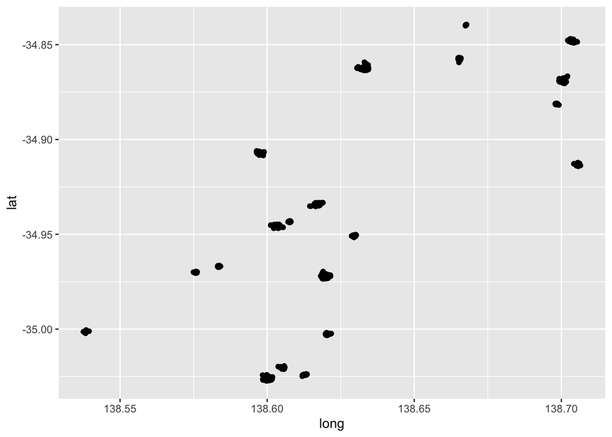

```r
cats |>
  ggplot(aes(x = long, y = lat)) +
  geom_point()
```

## 5.3 Draw a map, with color

In the code block below, create a scatter plot with longitude on the x-axis, latitude on the y-axis, and one point for each cat location in the data. Color the points based on the cat’s typical number of prey per month. Use the color-blind friendly `viridis` color scale.

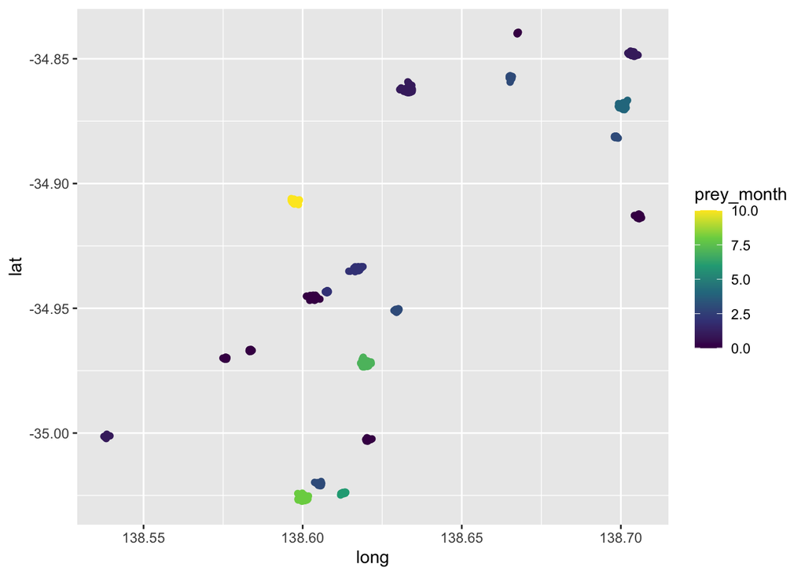

```r
cats |>
  ggplot(aes(x = long, y = lat, color = prey_month)) +
  geom_point() +
  scale_color_viridis_c()
```

## 5.4 Draw a map, with transparency

In the code block below, create another scatter plot, but only include male cats who are 9 or 10 years old. Make the points somewhat transparent so that your map shows areas where points overlap.

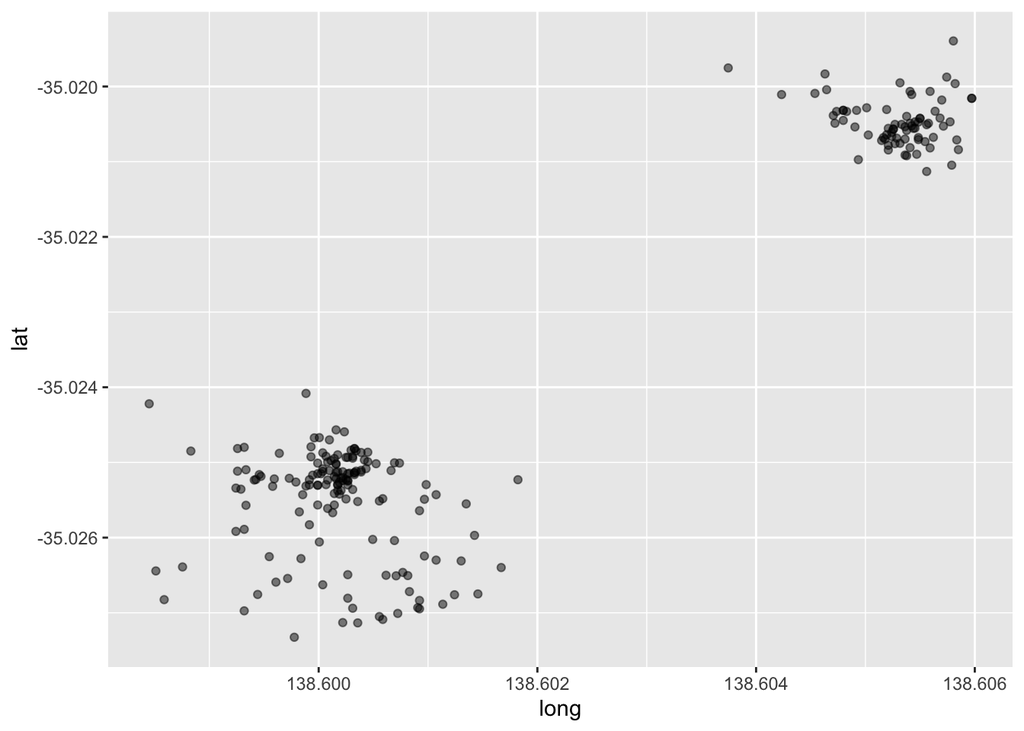

```r
cats |>
  filter(
    sex == "m",
    between(age, 9, 10)
  ) |>
  ggplot(aes(x = long, y = lat)) +
  geom_point(alpha = 0.5)
```

## 5.5 Draw a map with only one point per each cat

In the code block below, create another scatter plot with each cat’s average longitude on the x-axis, average latitude on the y-axis, and one point for each cat in the data. Label each point with the cat’s name. Try to put the names next to the points, not directly on top of them.

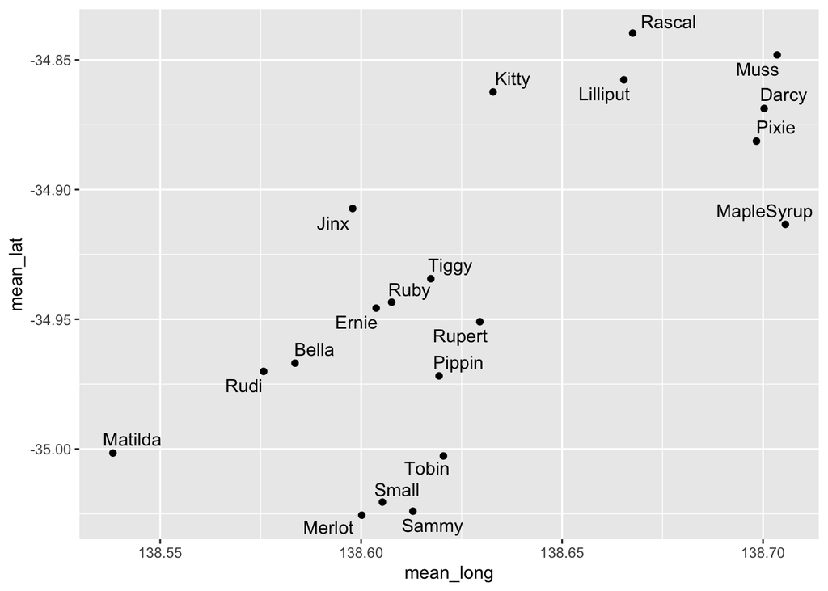

```r
cats |>
  group_by(name) |>
  summarize(
    mean_lat = mean(lat),
    mean_long = mean(long)
  ) |>
  ggplot(aes(x = mean_long, y = mean_lat, label = name)) +
  geom_point() +
  geom_text_repel()
```

## 5.6 East to west travel distance

In the code block below, create a bar graph with one bar for each cat (put the factor `name` on the y-axis) showing the total east-west distance they traveled (x-axis). Calculate east-west distance by subtracting the minimum longitude from the maximum longitude a cat reaches. Order the bars from smallest distance at the top to largest distance at the bottom.

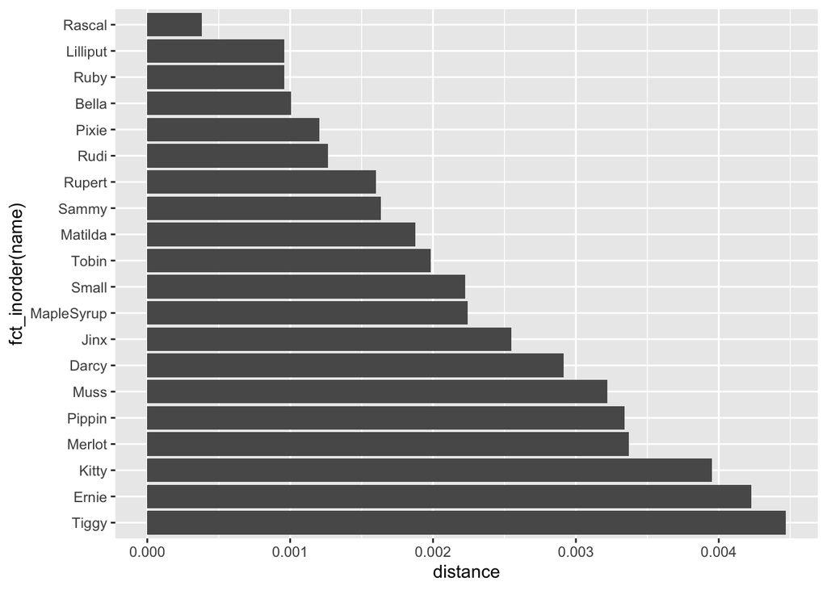

```r
cats |>
  group_by(name) |>
  summarize(distance = max(long) - min(long)) |>
  arrange(desc(distance)) |>
  ggplot(aes(x = distance, y = fct_inorder(name))) +
  geom_col()
```

## 5.7 Draw a scatter plot

Create a data set named `cat_traits` including only the variables `name`, `indoors_min`, `prey_month`, `age`, and `sex`. These variables are cat-specific, so they don’t change each time location is recorded. Therefore, the resulting table must only have **one** row per cat. Print `cat_traits` to confirm:

```r
cat_traits <- cats |>
  select(name, indoors_min, prey_month, age, sex) |>
  distinct()

cat_traits
```

| name | indoors_min | prey_month | age | sex |
| --- | --- | --- | --- | --- |
| Bella | 12 | 0 | 5.00 | f |
| Darcy | 12 | 4 | 8.00 | m |
| Ernie | 0 | 0 | 11.00 | m |
| Jinx | 6 | 10 | 6.00 | f |
| Kitty | 0 | 1 | 4.00 | m |
| Lilliput | 18 | 3 | 3.00 | f |
| MapleSyrup | 18 | 0 | 10.00 | f |
| Matilda | 12 | 1 | 8.00 | f |
| Merlot | 12 | 8 | 9.00 | m |
| Muss | 12 | 1 | 7.00 | m |

[output cut: 10 more lines]

Next, use `cat_traits` to create a scatter plot with cat age on the x-axis, prey per month on the y-axis, one point for each cat, and cats labeled by name.

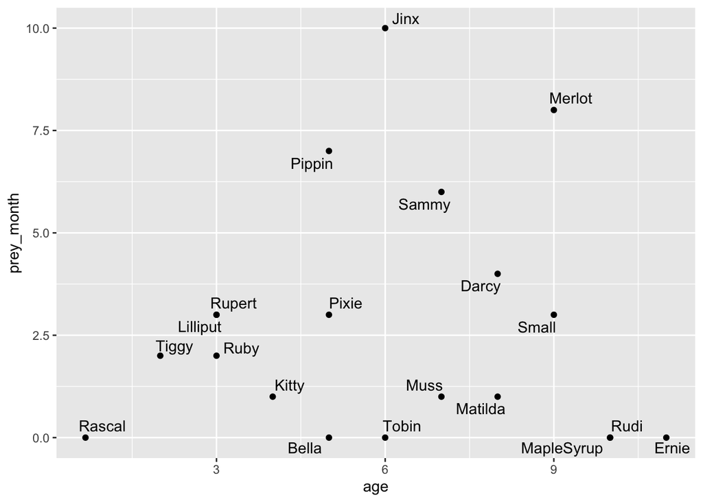

```r
cat_traits |>
  ggplot(aes(x = age, y = prey_month)) +
  geom_point() +
  geom_text_repel(aes(label = name))
```

## 5.8 Highlight points on a scatter plot

Starting with the same scatter plot you created in question 6, highlight the points for indoor cats (cats who spend 18 or more hours per day indoors) by coloring them `"navyblue"`. Label their names in non-overlapping `"navyblue"` text. Color the remaining points `"gray"` and do *not* include their names.

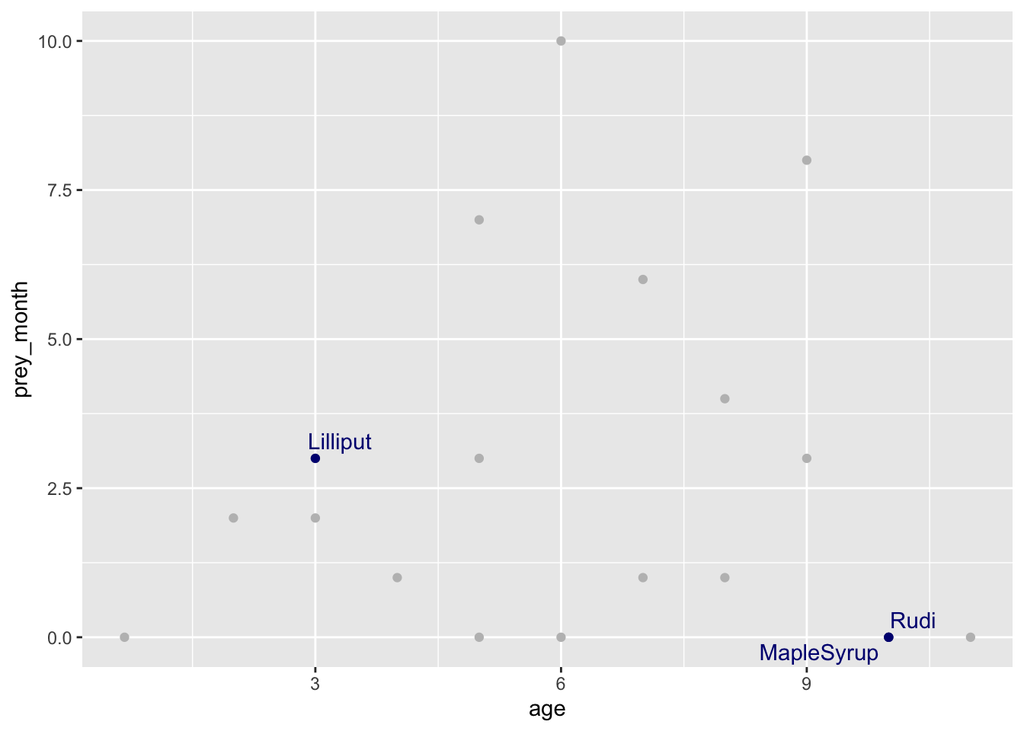

```r
indoor_cats <- cat_traits |> filter(indoors_min >= 18)

cat_traits |>
  ggplot(aes(x = age, y = prey_month)) +
  geom_point(color = "gray") +
  geom_point(data = indoor_cats, color = "navyblue") +
  geom_text_repel(
    data = indoor_cats,
    aes(label = name),
    color = "navyblue"
  )
```

## 5.9 Draw a line plot

In the code block below, use `cats` to draw a line plot with month on the x-axis and the total number of location recordings in a given month on the y-axis. Modify the scale of the x-axis to display months 1 to 12, with a grid-line for each month. The numbers 1 through 12 should appear as labels on the x-axis. There should also be a points layer on top of the line plot indicating the measurement in each month.

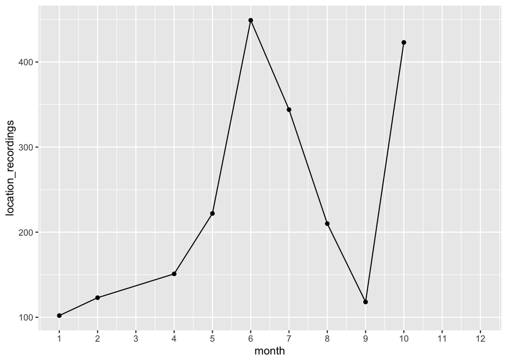

```r
cats |>
  group_by(month) |>
  summarize(location_recordings = n()) |>
  ggplot(aes(x = month, y = location_recordings)) +
  geom_line() +
  geom_point() +
  scale_x_continuous(limits = c(1, 12), n.breaks = 12)
```

## 5.10 Mean prey per month by age

Using `cats`, calculate the average prey per month based on each cat’s age. Plot the result as a bar chart. The y-axis should represent average prey kills. There should be one bar per age in years on the x-axis. Make the bars white with a black border.

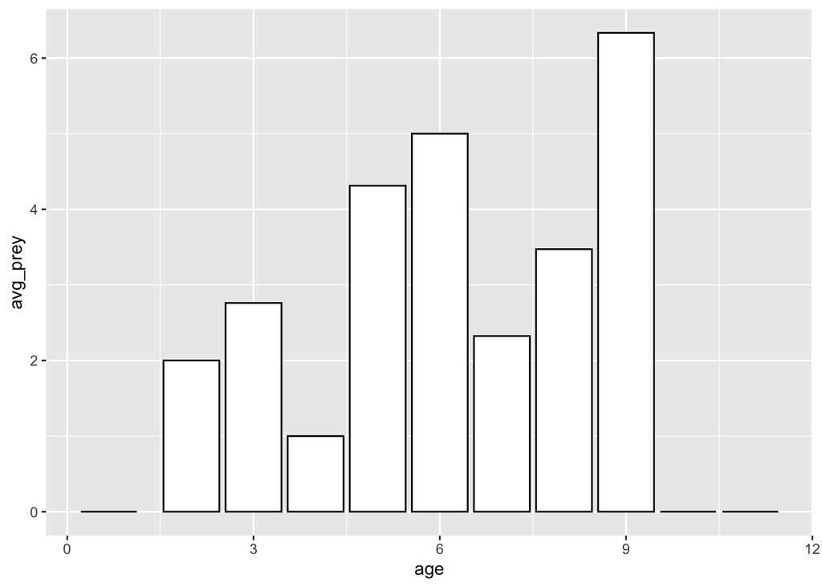

```r
cats |>
  group_by(age) |>
  summarize(avg_prey = mean(prey_month)) |>
  ggplot(aes(x = age, y = avg_prey)) +
  geom_col(fill = "white", color = "black")
```

## 5.11 Describe prey per month by cat sex

Using `cats`, create a table that summarizes the minimum, mean, and maximum number of prey killed per month grouped by sex. Return a 2x4 table with columns: `sex`, `min_prey`, `mean_prey`, and `max_prey`.

```r
cats |>
  group_by(sex) |>
  summarize(
    min_prey = min(prey_month),
    mean_prey = mean(prey_month),
    max_prey = max(prey_month)
  )
```

| sex | min_prey | mean_prey | max_prey |
| --- | --- | --- | --- |
| f | 0 | 3.205421 | 10 |
| m | 0 | 2.973629 | 8 |

## 5.12 Categorize cats by age group

Using `cats`, create a new variable called `age_group` that classifies cats into the following groups based on their age:

- `"young"` for cats less than 5 years old
- `"adult"` for cats between 5 and 10 years old (inclusive)
- `"senior"` for cats older than 10 years

Generate a table that shows each cat’s `name`, `age`, and their corresponding `age_group`. This table must only have one row per cat.

```r
cats |>
  mutate(age_group = case_when(
    age > 10 ~ "senior",
    age >= 5 ~ "adult",
    age < 5 ~ "young",
    TRUE ~ "default"
  )) |>
  select(name, age, age_group) |>
  distinct()
```

| name | age | age_group |
| --- | --- | --- |
| Bella | 5.00 | adult |
| Darcy | 8.00 | adult |
| Ernie | 11.00 | senior |
| Jinx | 6.00 | adult |
| Kitty | 4.00 | young |
| Lilliput | 3.00 | young |
| MapleSyrup | 10.00 | adult |
| Matilda | 8.00 | adult |
| Merlot | 9.00 | adult |
| Muss | 7.00 | adult |

[output cut: 10 more lines]

## 5.13 Calculate average outdoor time per cat

Using `cats` and the indoor time data, create a new column called `outdoors_avg` that calculates the *average* time each cat spends outdoors per day. Assume that the cat’s average indoor time is the average of the `indoors_min` and `indoors_max` columns.

Output a table that includes each cat’s name and `outdoors_avg`. Sort the table with the lowest average outdoor time first. The table should only have one row per cat.

```r
cats |>
  mutate(outdoors_avg = 24 - ((indoors_min + indoors_max) / 2)) |>
  select(name, outdoors_avg) |>
  distinct() |>
  arrange(outdoors_avg)
```

| name | outdoors_avg |
| --- | --- |
| Lilliput | 3.0 |
| MapleSyrup | 3.0 |
| Rudi | 3.0 |
| Bella | 9.5 |
| Darcy | 9.5 |
| Matilda | 9.5 |
| Merlot | 9.5 |
| Muss | 9.5 |
| Rascal | 9.5 |
| Ruby | 9.5 |

[output cut: 10 more lines]